# **Stack**

#### **Stack** adalah struktur data linier yang bekerja dengan prinsip LIFO (Last In, First Out), yaitu:

- Data yang terakhir dimasukkan akan menjadi data yang pertama dikeluarkan.
- Akses data hanya dilakukan pada satu sisi, yaitu bagian atas (top) stack.

Analogi Stack:

**Tumpukan piring → piring terakhir yang ditaruh akan diambil lebih dulu**

**Tumpukan buku → buku paling atas adalah yang pertama diambil**

#### Ciri utama stack antara lain:

- Akses data bersifat terbatas
- Elemen hanya dapat ditambah atau dihapus dari satu ujung
- Tidak mendukung akses acak (random access)
- Sangat cocok untuk proses rekursif dan backtracking

#### Operasi Dasar pada Stack

- **Push** Menambahkan elemen ke bagian atas stack.
- **Pop** Menghapus elemen paling atas dari stack.
- **Peek / Top** Melihat elemen teratas tanpa menghapusnya.
- **isEmpty** Mengecek apakah stack kosong.
- **Size** Mengetahui jumlah elemen dalam stack.

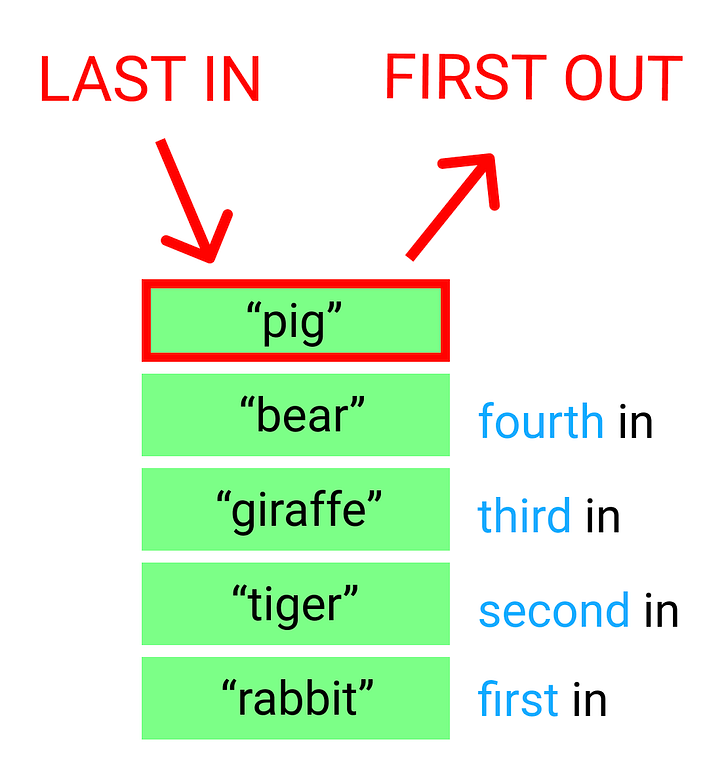

#### **CONTOH LATIHAN**

```python
def stack():
    s=[]
    return (s)
def push(s,data):
    s.append(data)
def pop(s):
    data=s.pop()
    return(data)
def peek(s):
    return(s[len(s)-1])
def isEmpty(s):
    return (s==[])
def size(s):
    return(len(s))
```

```python
def push(s.data):
    s.append(data)
```

```python
def __init__(self):
    self.items = []

def isEmpty(self):
    return self.items == []

def push(self, item):
    self.items.append(item)

def pop(self):
    return self.items.pop()

def peek(self):
    return self.items[len(self.items)-1]

def size(self):
    return len(self.items)

s=Stack()
s.push('hello')
s.push('true')
print(self.isEmpty)
print(s.peek())
While not self.isEmpty()
```

```python
def peak(self):
    return self.itmes[len(self.item)-1]
```

```python
def palindrome(teks):
    stack = []
    teks = teks.upper()
    for huruf in teks:
        stack.append(huruf)

    for huruf in teks:
        if huruf != stack.pop():
            return "Bukan Palindrome"

    return "Palindrome"

teksPalindrome = input("Masukkan sebuah kata: ")

hasil = palindrome(teksPalindrome)
print("Hasil:", hasil)
```

```
Hasil: Palindrome
```

```python
def palimdrome(huruf):
    katak=teks.stack()
for ch in huruf:
    teks.push(katak,ch)
```

### LATIHAN TUGAS

Riwayat Undo (Simulasi Undo Text Editor)

- Buatlah program sederhana untuk mensimulasikan fitur Undo pada editor teks.
- Riwayat Undo (Simulasi Undo Text Editor)
- Buatlah program sederhana untuk mensimulasikan fitur Undo pada editor teks.

**Ketentuan:**

- User memasukkan beberapa teks.
- Setiap input disimpan ke dalam stack.
- Jika user mengetik UNDO, maka teks terakhir dihapus.

**Contoh:**

**User memasukkan beberapa teks, setiap input disimpan ke dalam stack, Jika user mengetik UNDO, maka teks terakhir dihapus.**

**Contoh:**

- Input: Halo
- Input: Dunia
- Input: Belajar Stack
- Input: UNDO
- Output: Dunia

```python
stack = []
while True:
    teks = input("Input: ")

    if teks == "undo":
        stack.pop()
        break

    else:
        stack.append(teks)

print("Output:", stack[-1])
```

```
Output: buku
```

#### **Buat program untuk membalik urutan kata dalam sebuah kalimat menggunakan stack.**

```python
stack = []
kalimat = "Saya belajar struktur data"
kata = kalimat.split()

for k in kata:
    stack.append(k)

hasil = []
while stack:
    hasil.append(stack.pop())

n = " ".join(hasil)
print(n)
```

```
data struktur belajar Saya
```

#### Buat program yang: Mengisi stack dengan beberapa angka.

Menghitung jumlah elemen dalam stack tanpa menggunakan fungsi bawaan len()

```python
stack = []
stack.append(10)
stack.append(20)
stack.append(30)
stack.append(40)

jumlah = 0
for n in stack:
    jumlah += 1

print(stack)
print("jumlah elemen dalam stack:", jumlah)
```

```
[10, 20, 30, 40]
jumlah elemen dalam stack: 4
```

#### Diketahui stack berisi angka: [10, 20, 30, 40, 50]

Buat program untuk menghapus angka 30 tanpa merusak urutan elemen lainnya.

```python
urutan = [10, 20, 30, 40, 50]

stack = []

while urutan:
    angka = urutan.pop()

    if angka != 30:
        stack.append(angka)
while stack:
    urutan.append(stack.pop())

print(urutan)
```

```
[10, 20, 40, 50]
```

#### Parkiran Mobil (Model LIFO)

Sebuah parkiran hanya memiliki satu jalur masuk dan keluar (model stack).

Ketentuan:

Mobil masuk → push

Mobil keluar → pop

Jika parkiran penuh (maks 5 mobil) → tampilkan pesan

Buat program simulasi parkiran tersebut.

```python
parkiran = []
kapasitas_maks = 5

while True:
    print("\n=== MENU PARKIRAN ===")
    print("1. Mobil Masuk")
    print("2. Mobil Keluar")
    print("3. Lihat Parkiran")
    print("4. Keluar Program")

    pilihan = input("Pilih menu (1-4): ")

    if pilihan == "1":
        if len(parkiran) >= kapasitas_maks:
            print("Parkiran penuh! Tidak bisa menambah mobil.")
        else:
            mobil = input("Masukkan nomor mobil: ")
            parkiran.append(mobil)
            print(f"Mobil {mobil} masuk ke parkiran.")

    elif pilihan == "2":
        if len(parkiran) == 0:
            print("Parkiran kosong! Tidak ada mobil yang keluar.")
        else:
            mobil_keluar = parkiran.pop()
            print(f"Mobil {mobil_keluar} keluar dari parkiran.")

    elif pilihan == "3":
        if len(parkiran) == 0:
            print("Parkiran kosong.")
        else:
            print("Isi parkiran (urutan masuk):")
            i = 1
            for mobil in parkiran:
                print(f"{i}. {mobil}")
                i += 1

    elif pilihan == "4":
        print("Program selesai. Terima kasih!")
        break

    else:
        print("Pilihan tidak valid!")
```

```
=== MENU PARKIRAN ===
1. Mobil Masuk
2. Mobil Keluar
3. Lihat Parkiran
4. Keluar Program
```

```
Mobil 3 masuk ke parkiran.

=== MENU PARKIRAN ===
1. Mobil Masuk
2. Mobil Keluar
3. Lihat Parkiran
4. Keluar Program
```

```
Mobil 4 masuk ke parkiran.

=== MENU PARKIRAN ===
1. Mobil Masuk
2. Mobil Keluar
3. Lihat Parkiran
4. Keluar Program
```

```
Mobil 7 masuk ke parkiran.

=== MENU PARKIRAN ===
1. Mobil Masuk
2. Mobil Keluar
3. Lihat Parkiran
4. Keluar Program
```

```
Isi parkiran (urutan masuk):
1. 3
2. 4
3. 7

=== MENU PARKIRAN ===
1. Mobil Masuk
2. Mobil Keluar
3. Lihat Parkiran
4. Keluar Program
```

```
Mobil 7 keluar dari parkiran.

=== MENU PARKIRAN ===
1. Mobil Masuk
2. Mobil Keluar
3. Lihat Parkiran
4. Keluar Program
```

```
Isi parkiran (urutan masuk):
1. 3
2. 4

=== MENU PARKIRAN ===
1. Mobil Masuk
2. Mobil Keluar
3. Lihat Parkiran
4. Keluar Program
```

```
Program selesai. Terima kasih!
```

```python
stack_buku = []

while True:
    print("\n=== MENU PERPUSTAKAAN ===")
    print("1. Tambah Buku")
    print("2. Ambil Buku Paling Atas")
    print("3. Tampilkan Buku Paling Atas")
    print("4. Tampilkan Seluruh Buku")
    print("5. Keluar")

    pilihan = input("Pilih menu (1-5): ")

    if pilihan == "1":
        buku = input("Masukkan judul buku: ")
        stack_buku.append(buku)
        print(f"Buku '{buku}' berhasil ditambahkan.")

    elif pilihan == "2":
        if len(stack_buku) == 0:
            print("Stack kosong, tidak ada buku yang bisa diambil.")
        else:
            buku = stack_buku.pop()
            print(f"Buku '{buku}' diambil dari tumpukan.")

    elif pilihan == "3":
        if len(stack_buku) == 0:
            print("Stack kosong.")
        else:
            print("Buku paling atas:", stack_buku[-1])

    elif pilihan == "4":
        if len(stack_buku) == 0:
            print("Tidak ada buku dalam perpustakaan.")
        else:
            print("Daftar buku (dari atas ke bawah):")
            for buku in reversed(stack_buku):
                print("-", buku)

    elif pilihan == "5":
        print("Program selesai. Terima kasih!")
        break

    else:
        print("Pilihan tidak valid!")
```

```
=== MENU PERPUSTAKAAN ===
1. Tambah Buku
2. Ambil Buku Paling Atas
3. Tampilkan Buku Paling Atas
4. Tampilkan Seluruh Buku
5. Keluar
```

```
Buku 'anak yang hilang' berhasil ditambahkan.

=== MENU PERPUSTAKAAN ===
1. Tambah Buku
2. Ambil Buku Paling Atas
3. Tampilkan Buku Paling Atas
4. Tampilkan Seluruh Buku
5. Keluar
```

```
Buku 'anak yang durhaka' berhasil ditambahkan.

=== MENU PERPUSTAKAAN ===
1. Tambah Buku
2. Ambil Buku Paling Atas
3. Tampilkan Buku Paling Atas
4. Tampilkan Seluruh Buku
5. Keluar
```

```
Daftar buku (dari atas ke bawah):
- anak yang durhaka
- anak yang hilang

=== MENU PERPUSTAKAAN ===
1. Tambah Buku
2. Ambil Buku Paling Atas
3. Tampilkan Buku Paling Atas
4. Tampilkan Seluruh Buku
5. Keluar
```

```
Program selesai. Terima kasih!
```